# Preliminary Lesson 2: Environment & Functions

In the last lesson, we installed R and RStudio and toured the RStudio IDE. Now we’ll dig into the three concepts that everything else in this course builds on: the **environment**, where R keeps track of the names you’ve assigned; **functions**, the building blocks of every task R performs; and **objects**, the data upon which functions operate. For example, consider the following statement:

```r
1 + 1 + 2
```

```
[1] 4
```

The above statement was executed within the R **environment**. The numbers and the addition symbol are all R **objects**. The addition symbol is a type of object called a **function**. When the code was executed, R used the `+` function to calculate the sum of the values.

## Before you begin

To get the most out of this lesson, please:

- Open RStudio in a clean session.
- Open a new, blank script file and save it as “lesson_0.2.R”.
- Code along with the content.

We’ll close out with some best practices that will make your code easier to read (and easier to debug!) from the very start.

In this lesson, you will learn:

- What an environment is and how assignment (`<-`) works
- When quotation marks are (and are not) necessary
- How functions, arguments, and nested functions work
- How to install and load packages
- Best practices for commenting your code, naming your objects, and managing your global environment

Important! This lesson assumes that you have completed [Preliminary Lesson 1: R & RStudio](https://evansbrians.github.io/gis_2026/module_0/0.1_intro_to_r_and_rstudio/). The material here builds on that lesson, so please complete it before moving on.

Regardless of the application, coding in R involves working with:

- **Environments**: Data structures used to reference objects located in your system’s memory.
- **Functions**: Sets of instructions for accomplishing a given task. *Everything that happens in R is the result of a function call* (J. Chambers)!
- **Objects**: The values R works with, including vectors, functions, environments, and other structures. *Everything that exists in R is an object* (J. Chambers)!

## 1. The environment

An **environment** is a data structure that associates a set of **names** (also called *keys* or *bindings*) with objects located in your computer’s memory. R can use these names to retrieve the objects they are associated with.

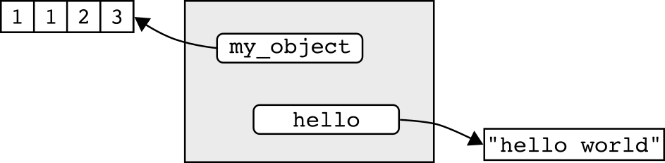

Adapted from [Advanced R](https://adv-r.hadley.nz/environments.html) by Hadley Wickham

In the diagram above, the “environment” (the gray box) associates names (white boxes with rounded edges) with data objects (white boxes with square edges). The objects shown are the numbers 1, 1, 2, and 3 and the phrase “hello world”. Note that the environment does not contain the objects themselves – it contains names that “point to” the objects. The objects are stored in your computer’s memory.

Names have objects; objects don’t have names.

– Hadley Wickham

### 1.1 Assignment

Working in the Source Pane

1. Type `hello`.
2. Add an assignment operator with the keyboard shortcut Alt + - (Mac: Option + -).
3. Type `"hello world"` (with quotes).
4. Run the code with the keyboard shortcut Ctrl + Enter (Mac: ⌘ + Return).

Have a look at the Environment tab of the Environment Pane. You should notice that the name `hello` has been assigned to your global environment. We can use this name (`hello`) to retrieve the object (“hello world”) from our system’s memory.

Calling objects

Type `hello` in your Console Pane and run it to see what it returns.

Watch how many names you have in your global environment!

Warning! Be aware of how many names are in your global environment. Each name represents an object that is stored in your system’s memory – an accumulation of large objects can reduce performance.

### 1.2 On the use of quotation marks

In every one of our classes, we are invariably asked why some words must be quoted and others do not. The environment is a good place to start with this common source of confusion.

Conversely, watch what happens when we type `my_object` into R:

```r
my_object
```

```
Error:
! object 'my_object' not found
```

We get an error! That’s because R cannot find a binding for the name `my_object` in an environment it can access (it will be able to shortly!).

We can, however, wrap `my_object` in quotation marks and R will not return an error:

```r
"my_object"
```

```
[1] "my_object"
```

What gives? `"my_object"` is a character value, so R returns it directly. In contrast, the unquoted name `my_object` tells R to search for a binding and retrieve the object associated with that name.

Single or double quotes?

Single and double quotation marks can largely be used interchangeably for words or phrases. We’ll learn best practices when using quotation marks in a later lesson.

## 2. Functions

**Functions** are what data-wrangling guru Hadley Wickham calls the “fundamental building block of R”. Functions are a special type of R object that contain instructions for executing a given task. Most computations in R involve one or more function calls.

For example, you actually used an R function when you ran `1 + 1 + 2`. The plus sign is a special type of R function called an **operator**. An operator is a function that is expressed as a symbol.

### 2.1 Using a named function

When you download R, you have access to thousands of functions. Most functions have names, and users run them by providing, in order:

1. The name of the function.
2. An opening parenthesis, `(`.
3. The argument(s) of the function.
4. A closing parenthesis, `)`.

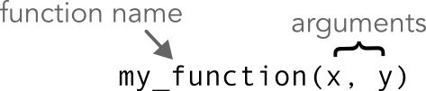

The **name** of a function is a pointer that your computer uses to find the instructions to execute when running the function. **Parentheses** are syntax that enclose a function’s arguments and indicate that the function should be called. The **arguments** of a function determine what you want your function to evaluate (usually the data) and often the behavior of the evaluation. If the function you are using contains more than one argument, each argument is separated by a **comma** – a comma is not a function but is instead syntax used to separate arguments in a function.

- `c()` is the R function used to combine multiple values into a single object.
- The parentheses `(...)` enclose the arguments of `c()`, which here are the individual values to combine, and tell R to call the function.
- The commas are syntax that separate the arguments of the function.
- The arguments of the function are the values that we would like to combine.

Space out your commas!

When using commas to delineate a function’s arguments, it’s best practice to include a trailing (but not leading) space after each comma.

An operator *is* a function that performs a specific operation but is written using a symbol or set of symbols instead of the usual `function_name(...)` syntax. The following are equivalent:

```r
1 + 2
```

```
[1] 3
```

```r
`+`(1, 2)
```

```
[1] 3
```

The advantage of using an operator is that it can simplify common tasks.

Probably the most important function in all of R is the `?` operator. We use `?` to show the help file for a given function in the Help tab of the Output Pane. The documentation includes a description of the function, how it is used, important details on its usage, the type of value returned, and even examples.

Getting help

Copy, paste, and run the code below in your Console Pane:

```r
?c
```

By running the `?` function above, we are provided with a description of the function, how it is used, its arguments, important considerations, and its return value. `?` will often return references to related functions and examples of the function’s usage.

Read the help files!

It’s *super important* to be able to read and understand R help files! When using an R function for the first time, be sure to read the help file for that function!

### 2.2 Nested functions

Functions can be nested inside other functions. In other words, you can run a function from within another function. This can help us avoid making unnecessary assignments.

### 2.3 Arguments that modify a function’s behavior

Many functions contain arguments in addition to the data object that you are evaluating. These arguments may modify the behavior of the function (*Note: Some arguments are necessary while some are optional*).

Let’s look at what happens when we try to calculate the mean of a set of values in which one value is `NA` (unknown):

```r
mean(
  c(5, 8, 13, NA)
)
```

```
[1] NA
```

If one of the values in a set is unknown, the value returned by `mean()` is also unknown by default. To address this, we can use an argument that modifies the default behavior of the function.

The `mean()` function contains an argument, `na.rm`, that tells R whether you want to remove `NA` prior to calculating the average (see `?mean`). We supply the additional argument after a comma:

```r
mean(
  c(5, 8, 13, NA),
  na.rm = TRUE
)
```

```
[1] 8.666667
```

Be careful!

- When functions contain more than one argument, placing each argument on its own line improves readability.
- Before you’re familiar with a function and its applications, it’s a good idea to read and re-read the function’s documentation (`?`) to get a sense of its arguments and usage.

Test your knowledge!

1. What does the `na.rm = TRUE` argument do in `mean(c(5, 8, 13, NA), na.rm = TRUE)`?

Removes the NA value before computing the mean Replaces NA with 0 Returns NA because a value is missing Rounds the result to a whole number

### 2.4 Packages of functions

R includes a default set of packages and functions, and countless additional functions have been written by members of the R community and assembled into **packages** that you can download. Many of these community-built packages are very powerful, and some are crucial to a modern workflow in R. The package we’ll use most in this class is the “tidyverse” package. It’s actually a **metapackage** – meaning that it is composed of other, smaller packages. To download one or more packages, you use the function `install.packages()`. This function evaluates the name of a package, in quotation marks, and installs it on your computer.

Installing packages

Please install the tidyverse metapackage:

```r
install.packages("tidyverse")
```

Install packages from the Console Pane!

Installing packages is not something you do every time you run a script in R. As such, package installation should occur in the Console Pane.

Once a package is installed on your computer, it is *almost* ready to use, but not quite. For example, the tidyverse metapackage installs stringr, the package that provides the `str_c()` function for combining character values. Can we use the function yet?

```r
str_c(
  c("Hello", "world"),
  collapse = " "
)
```

```
Error in `str_c()`:
! could not find function "str_c"
```

R couldn’t find it! That’s because stringr is installed but is not currently attached. Installed packages are stored in directories called **libraries**. To make a package’s exported functions available by name in the current R session, we use `library()` to load and attach the package. `library()` accepts either an unquoted package name or a package name in quotation marks; this course generally uses the unquoted form.

Loading libraries

Load the tidyverse metapackage, then run `str_c()` to combine “Hello” and “world” into a single value:

*Note: The `library()` function needs to be run each time a new R session is initiated. Because future lines of code may depend on the package or packages loaded, loading should always occur in the Source Pane.*

Watch out for the “package trap”!

Warning! In the early stages of learning R, or even later if you have not spent much time learning the language, you will find yourself falling into what I call the “package trap”. The package trap works like this:

1. You need to manipulate your data in an unfamiliar way.
2. You visit Stack Overflow and, while reading through the answers, find a package that will do what you want.
3. You install and load the package and *potentially* move past the issue.

*Why is this a problem?* Some of the packages you stumble on in this way will be critical to your current and future workflows – most will not. This workflow turns scripts into a sloppy patchwork of packages. It can make your code very confusing to follow and lead to unseen errors (if the function does not do exactly what you perceive it should). If the issue can be solved with base R or the packages you are currently working with, it will make your code clearer, help you avoid problems, and save you time in the future.

Test your knowledge!

## 3. Best practices in R coding

Throughout this course, you’ll learn a number of “best practices” that will make your code easier to read and limit some of the inevitable frustrations associated with coding in R.

### 3.1 Commenting code

It’s important to provide descriptive content that communicates your code to your future self and others. This is known as commenting a script. In R, you add a comment using a hashtag, `#`. R will not evaluate any text entered after a hashtag.

#### 3.1.1 Comments should be simple and clear

Adding comments is a bit of an art form. You want your comments to be descriptive enough to communicate a process but short enough such that they don’t contain unnecessary information.

Here’s an example of a very descriptive, but unnecessarily detailed, comment:

```r
# To practice adding numbers with the `+` function, I am
# adding the numbers 1, 2, and 3, with each number separated
# by `+`:

1 + 2 + 3
```

```
[1] 6
```

In the above, we can already see the values that are being added and that each number is separated by a `+` – that makes those elements of the comment unnecessary. The comment can therefore be reduced to:

```r
# To practice adding numbers:

1 + 2 + 3
```

```
[1] 6
```

… and of course we probably don’t need to know that the purpose of this line of code is “to practice”. We can therefore simplify our comment to:

```r
# Add numbers:

1 + 2 + 3
```

```
[1] 6
```

Think about your audience!

Take your target audience into consideration when commenting a script. If you are new to R or writing code for someone who is just starting out, your script should be full of comments that explain every potentially confusing process. When communicating to more advanced R users, you will likely need less commenting.

#### 3.1.2 In this course, comments should occur before executed code

In this course, place explanatory comments **before the code they describe**. Short end-of-line comments can sometimes be useful, but placing comments on their own lines is usually easier to read. In other words …

**Avoid this in course scripts**:

```r
1 + 2 + 3 # Add numbers
```

```
[1] 6
```

**Prefer this**:

```r
# Add numbers:

1 + 2 + 3
```

```
[1] 6
```

Format your comments consistently!

Consistent formatting of comments really helps with the legibility of your scripts. It’s best practice to:

- Include a blank line before and after your comment.
- Include one space between the hashtag and comment text.

### 3.2 Naming conventions

There are a few important rules to consider when assigning names to your global environment.

#### 3.2.2 Assignments and numbers

In our hunt for a more communicative assignment, we might be tempted to start our assigned name with a number:

```r
4instruments <-
  c(
    "vocals",
    "guitar",
    "bass",
    "drums"
  )
```

```
Error in parse(text = input): <text>:1:3: unexpected symbol
1: 4instruments
      ^
```

#### 3.2.3 Assignments with two or more words

```r
four instruments <-
  c(
    "vocals",
    "guitar",
    "bass",
    "drums"
  )
```

```
Error in parse(text = input): <text>:1:6: unexpected symbol
1: four instruments
         ^
```

Due to the space, we get an error message that there is an `unexpected symbol` in our assignment. This is because the space suggests that `four` and `instruments` refer to two separate objects.

#### 3.2.4 Use all lowercase letters when assigning names

The use of snake_case also avoids the use of uppercase letters. By specifying your assigned names in all lowercase, you limit the amount of information you have to remember when retrieving your assigned objects.

A naming convention to avoid

Another valid R naming convention uses a period to separate words (e.g., `four.instruments`). You may encounter this style in existing R functions and scripts. In this course, however, we will use snake_case consistently and avoid periods in the names we assign.

Which object-naming convention does the course favor, and why?

snake_case, because it is considered the easiest to read PascalCase, because it is the shortest period.case, because periods clearly separate words camelCase, because it avoids underscores

### 3.3 Managing your global environment

Managing the names in your global environment helps you better organize your workflow and avoid performance issues due to memory limitations. In doing so, it’s important to **maintain only the names that you’ll need**. Let’s take a moment to explore the names assigned to our global environment.

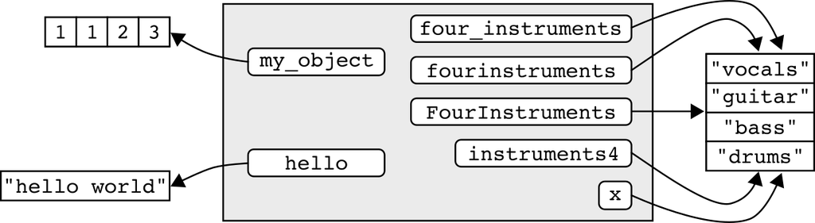

Looks crazy, right? One glaring issue is that we have several different names assigned to the same data object. This reveals something special about how R uses assignments – because the names point to the *same* data object, R is able to reduce the amount of data that must be stored in memory. That being said, this redundancy is not necessary.

True or false: Assigning two different names to the same set of values stores two independent copies of the data in memory, one for each name.

We can remove names from the global environment using the `rm()` function. Inside of the parentheses, we supply the names that we would like to remove, with each name separated by a comma.

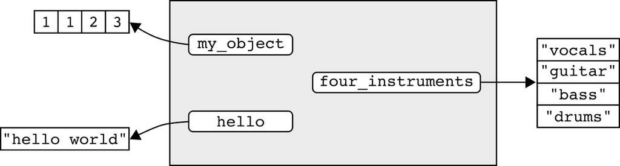

Although we’ve improved the organization of the global environment, we haven’t really saved much in terms of memory allocation. That’s because R only had to store additional names, not copies of the data object itself. To save memory, we need to remove a name that is uniquely assigned to an object.

Use `rm()` to remove the assignment `hello` from your global environment.

```r
rm(hello)
```

List the current names in the global environment.

```r
ls()
```

By removing the assignment `hello` above, the data object “hello world” was left without a reference in the global environment. Because of this, the data will be automatically removed from memory (*Note: This process is known as garbage collection*).

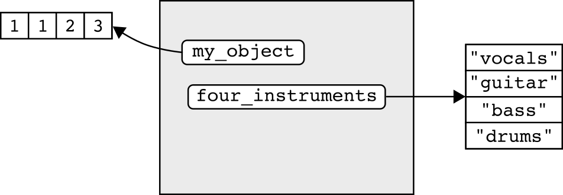

Some key rules regarding assignments

- Only define an object if you truly want to use it in the future.
- Do not overwrite assignments (i.e., do not assign the same name to a modified version of an object).
- Do not assign names to multiple versions of the same object (e.g., `fourInstruments` and `four_instruments`).

## 4. Exercises

Test your knowledge!

1. Which of the following statements is TRUE?

An operator is not a function All functions are followed by parentheses An R function is a type of object The arguments of a function cannot include more than one data object

Consider the following code, then answer the questions that follow:

```r
my_values <-
  c(1, 1, 2 + 3)
```

2. TRUE/FALSE: Upon execution, the name `my_values` is added to the global environment, but the data object itself is stored in your system’s memory.
3. How many functions are present in the above code?

0 3 1 2

4. TRUE/FALSE: The above code should be written in the Source Pane.

## Take-home points

Here’s the short version of what to carry forward from this lesson:

- An **environment** maps names to objects. Remember Hadley’s line – “names have objects; objects don’t have names” – so several names can point to the very same object, and R is smart enough not to duplicate that object in memory.
- Use the assignment operator `<-` to give an object a name so it sticks around in your global environment. Without assignment, an object exists just long enough to print and is then gone.
- Whether a word needs quotes depends on how you want R to treat it: a bare word is a reference (a name R looks up in the environment), while a quoted word is treated as plain data.
- Nested functions evaluate from the inside out, so the inner function (like `c()`) runs before the outer one (like `mean()`) ever sees its result.
- Many functions take extra arguments that change their behavior – `na.rm = TRUE` in `mean()` is the classic example, telling R to drop missing values before computing.
- Install packages once with `install.packages()` (name in quotes, run from the Console Pane), but load them every session with `library()` (using the course’s unquoted-name style and keeping the call in your Source Pane). And watch out for the “package trap” – don’t collect a new package every time Stack Overflow suggests one.
- In this course, place explanatory comments on the line *before* the code, with one space after the `#`, and use snake_case for names: all lowercase, no spaces, and never starting with a number. Periods are valid in R names, but we will avoid them for consistency.
- Keep your global environment tidy – use `ls()` to see what’s there and `rm()` to clear out names you no longer need. Once the last name pointing to an object is gone, garbage collection frees that object from memory.

## Reference

- **Arguments**: A value supplied to a function that modifies its behavior when the function runs.
- **Environment**: A dimensionless data structure that contains references (names) to data stored in memory.
- **Function**: A set of instructions (stored as an R object) used to complete a given task.
- **Metapackage**: A package that is comprised of more than one smaller packages.
- **Name**: A reference that R uses to call data from your computer’s memory (also called an “assignment”, “key”, or “binding”).
- **Nested function**: A function that is run inside of another function.
- **Operator**: A function expressed that is expressed as a symbol and is not followed by parentheses.

**Important!** Primitive functions, as well as functions in the packages that R attaches by default (e.g., *base*, *utils*, *stats*, and *graphics*), are available as soon as you start an R session.

| Package | Function | Definition |
| --- | --- | --- |
| .Primitive | + | Infix arithmetic operator (addition) |
| .Primitive | <- | Infix operator that assigns an object on the right-hand-side (RHS) to a name on the left-hand-side (LHS) -- this should be used for global assignments! |
| .Primitive | = | Infix operator that assigns an object on the right-hand-side (RHS) to a name on the left-hand-side (LHS) -- this should not be used for global assignments! |
| .Primitive | c | Combine values to form an atomic vector |
| base | library | Attach the package environment for a given package to the current R session |
| base | ls | Generate a character vector of names in a specified environment (default is the global environment) |
| base | mean | Generate a one-value double numeric vector that describes the mean of a vector |
| base | rm | Remove a name from a specified environment (default is the global environment) |
| stringr | str_c | Concatenate strings, with or without (default) a separator |
| utils | ? | Prefix operator to retrieve the help file for a function |
| utils | install.packages | Download and install one or more packages onto your computer. |

The most common keyboard shortcuts are provided below for Windows and Mac operating systems.

| Task | Windows | Mac |
| --- | --- | --- |
| View all keyboard shortcuts | Alt + ⇧ + K | ⌥ + ⇧ + K |
| Open an existing script | Ctrl + O | ⌘ + O |
| Create a new script | Ctrl + ⇧ + N | ⌘ + ⇧ + N |
| Save script file | Ctrl + S | ⌘ + S |
| Execute code | Ctrl + Enter | ⌘ + Return |
| Copy | Ctrl + C | ⌘ + C |
| Paste | Ctrl + V | ⌘ + V |
| Add a pipe operator | Ctrl + ⇧ + M | ⌘ + ⇧ + M |
| Add an assignment operator | Alt + dash | ⌥ + dash |
| Add a new code section | Ctrl + ⇧ + R | ⌘ + ⇧ + R |
| Indent code | Ctrl + I | ⌘ + I |